# Segmentation and MBA based on cluster labels

```python
import pandas as pd
import numpy as np
import time
import glob
from math import ceil

# association rules
from mlxtend.frequent_patterns import apriori
from mlxtend.frequent_patterns import association_rules

from sklearn.preprocessing import StandardScaler
from sklearn.metrics import silhouette_score, silhouette_samples
from sklearn import preprocessing

# dimensionality reduction
from sklearn.decomposition import PCA
from sklearn.decomposition import TruncatedSVD
from sklearn.manifold import TSNE

# clustering
from sklearn.cluster import KMeans, MiniBatchKMeans
from sklearn.cluster import OPTICS
from scipy.cluster.hierarchy import dendrogram, linkage
from sklearn.mixture import GaussianMixture
from yellowbrick.cluster import KElbowVisualizer

import matplotlib.pyplot as plt
import seaborn as sns
import squarify

import pandas.plotting

print('--- packages imported ---')
```

```
--- packages imported ---
```

```python
!export PYTHONWARNINGS="ignore"
```

```python
!ls
```

```
BC3_EDA_1.ipynb
Clustering Analysis and MBA.ipynb
Clustering Analysis.ipynb
Clustering Analysis_max.ipynb
Clustering_Analysis_and_MBA_per_Cluster-Copy1.ipynb
Freq_coms_coordination.png
Freq_coms_heatmap.png
MBA-modified-Copy1.ipynb
MBA-modified.ipynb
MBA-modified_max.ipynb
MBA.ipynb
Occ_coms_heatmap.png
Preprocessing_orders.ipynb
Preprocessing_orders_depar.ipynb
README.md
all_coms_conv_heatmap.png
all_coms_heatmap.png
all_subs_heatmap.png
clusters.csv
clusters_dp.csv
clusters_pt.csv
departments.csv
heatmap.png
heatmap_freq_com.png
heatmap_freq_occ.png
heatmap_freq_occ_20.png
heatmap_freq_sub.png
heatmap_sub_occ_20.png
heatmap_subs.png
img
order_products.csv
orders.csv
orders_dataframe.csv
products.csv
pt_one.csv
pt_three.csv
pt_two.csv
scatter_conf_support.png
total_subs_heatmap.png
```

## Import datasets

```python
departments = pd.read_csv('departments.csv')
order_prod = pd.read_csv('order_products.csv', usecols=['order_id', 'product_id'])
orders = pd.read_csv('orders.csv')
products = pd.read_csv('products.csv')
```

## 1. Preprocessing and Transformation

```python
df = pd.merge(order_prod, products, how='left', on='product_id').\
    drop(["product_id", "department_id"], axis=1)
df.head()
```

|  | order_id | product_name |
| --- | --- | --- |
| 0 | 10 | fresh fruits |
| 1 | 10 | fresh vegetables |
| 2 | 10 | fresh herbs |
| 3 | 10 | fresh fruits |
| 4 | 10 | fresh vegetables |

```python
orders.head()
```

|  | order_id | user_id | order_number | order_dow | order_hour_of_day | days_since_prior_order |
| --- | --- | --- | --- | --- | --- | --- |
| 0 | 2425083 | 49125 | 1 | 2 | 18 | NaN |
| 1 | 1944304 | 162867 | 1 | 3 | 17 | NaN |
| 2 | 1201011 | 147243 | 14 | 0 | 16 | 3.0 |
| 3 | 1906860 | 195275 | 81 | 1 | 11 | 3.0 |
| 4 | 2766469 | 58222 | 3 | 6 | 11 | 6.0 |

The column *days_since_prior_order* has 12254 *Nan* values which is due to the obvious lack of information when a customer has made purchase for the first time. Hence, for first time customers, the *days_since_prior_order* is *Nan*.  
**As a result, we need to identify these customers and create a seperate dataframe if we want to integrate the feature *days_since_prior_order* in our clustering algorithm.**

### 1.1. Reshaping data to have user_id as index

We will employ a customer segmentation to group Instacarts shoopers according to their purchases. That is, we need to reshape and transform the data.

```python
op_merged = pd.merge(order_prod, products, how='left', on='product_id')
op_merged = pd.merge(op_merged, departments, on='department_id', how='left')
op_merged_pt = op_merged.drop(["product_id","department_id","department"], axis=1)
```

```python
# use crosstab to pivot data
pt_cross = pd.crosstab(op_merged_pt['order_id'], op_merged_pt['product_name'])
# check sum of all purchases made. Important info to check if our transformation was successful at the end.
pt_cross.values.sum()
```

```
2019501
```

```python
# merge pivoted order df with user_id
pt_merge = pd.merge(pt_cross.reset_index(), orders, how='left', on='order_id')
pt_merge = pt_merge.drop(pt_merge.columns[-4:], axis=1).drop("order_id", axis=1)
```

```python
# melt df on user_id
pt_melt = pd.melt(pt_merge, id_vars=['user_id'], value_vars=pt_merge.columns[:-1])
pt_melt = pt_melt.groupby(["user_id", "variable"])["value"].sum().reset_index()
```

```python
# pivot data to get all purchases (columns= product types) made by the user (row)
pt_pivot = pt_melt.pivot_table(index="user_id", columns='variable', values='value')
pt_pivot.head()
```

| variable user_id | air fresheners candles | asian foods | baby accessories | baby bath body care | baby food formula | bakery desserts | baking ingredients | baking supplies decor | beauty | beers coolers | ... | spreads | tea | tofu meat alternatives | tortillas flat bread | trail mix snack mix | trash bags liners | vitamins supplements | water seltzer sparkling water | white wines | yogurt |
| --- | --- | --- | --- | --- | --- | --- | --- | --- | --- | --- | --- | --- | --- | --- | --- | --- | --- | --- | --- | --- | --- |
| 2 | 0 | 0 | 0 | 0 | 0 | 0 | 0 | 0 | 0 | 0 | ... | 0 | 0 | 0 | 0 | 0 | 0 | 0 | 0 | 0 | 0 |
| 3 | 0 | 0 | 0 | 0 | 0 | 0 | 0 | 0 | 0 | 0 | ... | 1 | 0 | 0 | 0 | 0 | 0 | 0 | 1 | 0 | 0 |
| 7 | 0 | 0 | 0 | 0 | 0 | 0 | 0 | 0 | 0 | 0 | ... | 0 | 0 | 0 | 0 | 0 | 0 | 0 | 0 | 0 | 1 |
| 10 | 0 | 0 | 0 | 0 | 0 | 0 | 0 | 0 | 0 | 0 | ... | 0 | 0 | 0 | 0 | 0 | 0 | 0 | 0 | 0 | 1 |
| 11 | 0 | 0 | 0 | 0 | 0 | 0 | 2 | 0 | 0 | 0 | ... | 1 | 0 | 0 | 0 | 0 | 0 | 0 | 2 | 0 | 0 |

5 rows × 134 columns

```python
# Check if transformation was successful and matches original df length. It does!
pt_pivot.values.sum()
```

```
2019501
```

```python
pt_pivot.shape
```

```
(105273, 134)
```

### 1.2. Separating the new customers (with days since prior purchases = Nan) from the customer with +1 purchase

To perform Clustering we decided to drop all rows that contain Nan values in date since prior order, since keeping them or attributing a number to those Nan values would bias our results. That is we have **105273** customers, **12254** being new customers. BUT, since a new customer could order multiple times in the given period it would be wrong to delete them. So, we deleted only the new customers that shopped one time and one time only as well as the first orders of the new customers containing the Nan values. At end end we are left with **98918** that shopped at least twice in the given period/dataset.

```python
orders_df = orders.copy()
```

```python
orders_df.set_index('order_id',inplace=True)
```

```python
new_cus = orders_df[orders_df['days_since_prior_order'].isnull()]
new_cus.drop(columns=['days_since_prior_order'], inplace=True)
```

```python
orders_cust = orders_df[orders_df['days_since_prior_order'].notna()]
```

```python
if (new_cus.shape[0] + orders_cust.shape[0] == orders_df.shape[0]) == True:
    print('New customer orders:',new_cus.shape[0])
    print('Current customer orders:',orders_cust.shape[0])
    print('Slicing successful!')
```

```
New customer orders: 12254
Current customer orders: 187746
Slicing successful!
```

**Aggregating the orders_cust df as follows:**  
Taking the max order_numer,  
mean day_since_prior_order,  
mean order_dow,  
mean order_hour_of_day.

```python
users_df = orders_cust.groupby('user_id').agg({'order_number':'max',
                                             'days_since_prior_order':'mean',
                                             'order_dow':'mean',
                                             'order_hour_of_day':'mean'})\
                               .rename(columns={"order_number":"purchases"})
users_df.head()
```

| user_id | purchases | days_since_prior_order | order_dow | order_hour_of_day |
| --- | --- | --- | --- | --- |
| 2 | 3 | 6.500000 | 3.000000 | 10.000000 |
| 3 | 11 | 13.333333 | 1.666667 | 18.333333 |
| 7 | 3 | 30.000000 | 0.000000 | 18.000000 |
| 10 | 4 | 14.000000 | 3.000000 | 15.000000 |
| 11 | 5 | 30.000000 | 5.000000 | 11.000000 |

```python
users_df.shape
```

```
(98918, 4)
```

### 1.3. Merging the new user_df with our pt_pivot which entails consumption behaviour data

```python
all_users_df = users_df.merge(pt_pivot, how='left', on='user_id')
all_users_df.head()
```

| user_id | purchases | days_since_prior_order | order_dow | order_hour_of_day | air fresheners candles | asian foods | baby accessories | baby bath body care | baby food formula | bakery desserts | ... | spreads | tea | tofu meat alternatives | tortillas flat bread | trail mix snack mix | trash bags liners | vitamins supplements | water seltzer sparkling water | white wines | yogurt |
| --- | --- | --- | --- | --- | --- | --- | --- | --- | --- | --- | --- | --- | --- | --- | --- | --- | --- | --- | --- | --- | --- |
| 2 | 3 | 6.500000 | 3.000000 | 10.000000 | 0 | 0 | 0 | 0 | 0 | 0 | ... | 0 | 0 | 0 | 0 | 0 | 0 | 0 | 0 | 0 | 0 |
| 3 | 11 | 13.333333 | 1.666667 | 18.333333 | 0 | 0 | 0 | 0 | 0 | 0 | ... | 1 | 0 | 0 | 0 | 0 | 0 | 0 | 1 | 0 | 0 |
| 7 | 3 | 30.000000 | 0.000000 | 18.000000 | 0 | 0 | 0 | 0 | 0 | 0 | ... | 0 | 0 | 0 | 0 | 0 | 0 | 0 | 0 | 0 | 1 |
| 10 | 4 | 14.000000 | 3.000000 | 15.000000 | 0 | 0 | 0 | 0 | 0 | 0 | ... | 0 | 0 | 0 | 0 | 0 | 0 | 0 | 0 | 0 | 1 |
| 11 | 5 | 30.000000 | 5.000000 | 11.000000 | 0 | 0 | 0 | 0 | 0 | 0 | ... | 1 | 0 | 0 | 0 | 0 | 0 | 0 | 2 | 0 | 0 |

5 rows × 138 columns

```python
# Check
print(len(all_users_df.index))
print(len(all_users_df.index.unique()))
```

```
98918
98918
```

### 1.4. Scaling the Data

```python
df_before = all_users_df.copy()

cols = all_users_df.columns
rows = all_users_df.index

dic = {}
i = 0

for element in cols:
    dic[i]=element
    i = i + 1

x = all_users_df.values #returns a numpy array
min_max_scaler = preprocessing.MinMaxScaler()
x_scaled = min_max_scaler.fit_transform(x)
df_scaled = pd.DataFrame(x_scaled)
df_scaled = df_scaled.rename(columns=dic)
df_scaled.head()
```

|  | purchases | days_since_prior_order | order_dow | order_hour_of_day | air fresheners candles | asian foods | baby accessories | baby bath body care | baby food formula | bakery desserts | ... | spreads | tea | tofu meat alternatives | tortillas flat bread | trail mix snack mix | trash bags liners | vitamins supplements | water seltzer sparkling water | white wines | yogurt |
| --- | --- | --- | --- | --- | --- | --- | --- | --- | --- | --- | --- | --- | --- | --- | --- | --- | --- | --- | --- | --- | --- |
| 0 | 0.010204 | 0.216667 | 0.500000 | 0.434783 | 0.0 | 0.0 | 0.0 | 0.0 | 0.0 | 0.0 | ... | 0.000000 | 0.0 | 0.0 | 0.0 | 0.0 | 0.0 | 0.0 | 0.000000 | 0.0 | 0.000000 |
| 1 | 0.091837 | 0.444444 | 0.277778 | 0.797101 | 0.0 | 0.0 | 0.0 | 0.0 | 0.0 | 0.0 | ... | 0.083333 | 0.0 | 0.0 | 0.0 | 0.0 | 0.0 | 0.0 | 0.022222 | 0.0 | 0.000000 |
| 2 | 0.010204 | 1.000000 | 0.000000 | 0.782609 | 0.0 | 0.0 | 0.0 | 0.0 | 0.0 | 0.0 | ... | 0.000000 | 0.0 | 0.0 | 0.0 | 0.0 | 0.0 | 0.0 | 0.000000 | 0.0 | 0.007143 |
| 3 | 0.020408 | 0.466667 | 0.500000 | 0.652174 | 0.0 | 0.0 | 0.0 | 0.0 | 0.0 | 0.0 | ... | 0.000000 | 0.0 | 0.0 | 0.0 | 0.0 | 0.0 | 0.0 | 0.000000 | 0.0 | 0.007143 |
| 4 | 0.030612 | 1.000000 | 0.833333 | 0.478261 | 0.0 | 0.0 | 0.0 | 0.0 | 0.0 | 0.0 | ... | 0.083333 | 0.0 | 0.0 | 0.0 | 0.0 | 0.0 | 0.0 | 0.044444 | 0.0 | 0.000000 |

5 rows × 138 columns

### 1.4. Performing PCA for Dimensionality Reduction

```python
def explained_variance(dataframe):
    """Calculates the Eigenvalues for each Principal Component in a dataframe."""

    pca = PCA()
    pca_feat = pca.fit_transform(dataframe)

    return np.cumsum(pca.explained_variance_ratio_), pca.n_components_
```

```python
def get_principal_components(dataframe, nPC):
    """Gets PC values for each observation in dataframe and creates new dataframe."""

    pca = PCA(nPC)
    pca_feat = pca.fit_transform(dataframe)
    pca_names = [f"PC{i}" for i in range(pca.n_components_)]
    pca_df = pd.DataFrame(pca_feat, index=dataframe.index, columns=pca_names)
    return pca_df
```

```python
explained_variance(df_scaled)
```

```
(array([0.27192185, 0.5086467 , 0.58640197, 0.65466772, 0.67995344,
        0.69016915, 0.69873972, 0.70698652, 0.71477093, 0.72195173,
        0.72898325, 0.73550944, 0.74176419, 0.74786375, 0.75362461,
        0.75928461, 0.76433432, 0.76920514, 0.7738792 , 0.77847542,
        0.7828491 , 0.78719961, 0.79148383, 0.79572777, 0.79978451,
        0.80378409, 0.80768931, 0.81156896, 0.81539207, 0.81919294,
        0.82279205, 0.82635953, 0.82983152, 0.83328   , 0.83668492,
        0.84003827, 0.84333359, 0.84660024, 0.84976182, 0.85286876,
        0.85592691, 0.85894559, 0.86194403, 0.86492373, 0.8678456 ,
        0.87073094, 0.87357073, 0.8763628 , 0.87913975, 0.88186761,
        0.88450085, 0.8871207 , 0.8897037 , 0.89226327, 0.89477953,
        0.89726265, 0.8997285 , 0.90218019, 0.90459977, 0.90700771,
        0.90938881, 0.91175227, 0.91409163, 0.9164004 , 0.91868971,
        0.92093017, 0.92316565, 0.92530186, 0.9274032 , 0.92945536,
        0.93149962, 0.93348501, 0.93543489, 0.9373219 , 0.93919235,
        0.94097009, 0.94273894, 0.94440936, 0.94607382, 0.94771814,
        0.94933121, 0.95092012, 0.95246328, 0.95398336, 0.95548756,
        0.9569581 , 0.95841813, 0.95983308, 0.96122797, 0.96259541,
        0.96392699, 0.96524267, 0.96654033, 0.96782408, 0.96907876,
        0.9702963 , 0.97149905, 0.97266199, 0.97380409, 0.97491572,
        0.97600029, 0.97707262, 0.97812488, 0.97917177, 0.98021684,
        0.98124256, 0.98222791, 0.98316392, 0.98405991, 0.98493591,
        0.98577745, 0.98660572, 0.98740612, 0.98818919, 0.98895639,
        0.98969701, 0.99038973, 0.99107202, 0.99175099, 0.9924029 ,
        0.99302623, 0.99363038, 0.99420624, 0.99474527, 0.99526775,
        0.99576934, 0.9962668 , 0.99675626, 0.99723519, 0.9976895 ,
        0.99809176, 0.9984594 , 0.99879501, 0.99908429, 0.9993518 ,
        0.99960049, 0.99984641, 1.        ]),
 138)
```

**Result:**  
PCA 10, subjective assessment

```python
scaled = get_principal_components(df_scaled, 10)
```

```python
scaled
```

|  | PC0 | PC1 | PC2 | PC3 | PC4 | PC5 | PC6 | PC7 | PC8 | PC9 |
| --- | --- | --- | --- | --- | --- | --- | --- | --- | --- | --- |
| 0 | 0.160751 | 0.009794 | -0.173143 | 0.199828 | 0.023177 | -0.012133 | -0.026177 | 0.029972 | -0.029614 | 0.035752 |
| 1 | -0.062577 | -0.172641 | -0.093880 | -0.192661 | 0.024529 | -0.049864 | -0.017797 | 0.003937 | -0.019044 | 0.071958 |
| 2 | -0.656021 | -0.343061 | 0.015032 | -0.199400 | 0.019417 | -0.024406 | -0.025816 | -0.017935 | -0.058038 | 0.010893 |
| 3 | -0.052328 | 0.049258 | -0.064274 | -0.053157 | 0.191100 | 0.120482 | -0.081305 | -0.035371 | -0.028670 | -0.096082 |
| 4 | -0.491170 | 0.473390 | 0.105764 | 0.096871 | 0.004902 | 0.010408 | 0.134067 | -0.049935 | -0.030227 | 0.052764 |
| ... | ... | ... | ... | ... | ... | ... | ... | ... | ... | ... |
| 98913 | 0.089191 | 0.361842 | -0.078113 | 0.267075 | 0.110681 | -0.046084 | 0.002299 | -0.017022 | -0.094977 | -0.086612 |
| 98914 | 0.110528 | 0.360492 | -0.204733 | -0.057756 | -0.005510 | 0.002354 | -0.002157 | 0.016804 | -0.017037 | 0.011676 |
| 98915 | 0.384999 | -0.242268 | 0.116580 | -0.199926 | -0.187555 | -0.037846 | 0.000299 | -0.011871 | -0.008063 | -0.066668 |
| 98916 | 0.223731 | -0.257199 | 0.231551 | -0.014102 | -0.096822 | 0.021008 | 0.099039 | 0.069955 | -0.015660 | 0.015913 |
| 98917 | -0.135919 | 0.236994 | -0.031005 | -0.128984 | 0.022502 | -0.032861 | -0.024262 | -0.043843 | 0.063334 | 0.076393 |

98918 rows × 10 columns

## 2. Clustering Shoppers

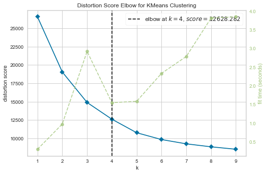

```python
# KMEANS Elbow
model = KMeans(scaled)
visualizer = KElbowVisualizer(model, k=(1,10))

visualizer.fit(scaled)
visualizer.show()       # Finalize and render the figure
```

### 2.1. Running K-Means with 4 clusters and random_state = 27

```python
number_clusters = 4
kmeans = KMeans(
    n_clusters=number_clusters,
    init='k-means++',
    n_init=10,
    random_state=27,
    tol= 1e-4)

km_labels = kmeans.fit_predict(scaled)
km_labels
```

```
array([3, 0, 2, ..., 1, 1, 3], dtype=int32)
```

### 2.2. Merging cluster labels with original df

```python
all_users_df.reset_index(drop=True,inplace=True)
```

```python
clusters = pd.concat((all_users_df, pd.Series(km_labels, name='labels')), axis=1)
clusters.head()
```

|  | purchases | days_since_prior_order | order_dow | order_hour_of_day | air fresheners candles | asian foods | baby accessories | baby bath body care | baby food formula | bakery desserts | ... | tea | tofu meat alternatives | tortillas flat bread | trail mix snack mix | trash bags liners | vitamins supplements | water seltzer sparkling water | white wines | yogurt | labels |
| --- | --- | --- | --- | --- | --- | --- | --- | --- | --- | --- | --- | --- | --- | --- | --- | --- | --- | --- | --- | --- | --- |
| 0 | 3 | 6.500000 | 3.000000 | 10.000000 | 0 | 0 | 0 | 0 | 0 | 0 | ... | 0 | 0 | 0 | 0 | 0 | 0 | 0 | 0 | 0 | 3 |
| 1 | 11 | 13.333333 | 1.666667 | 18.333333 | 0 | 0 | 0 | 0 | 0 | 0 | ... | 0 | 0 | 0 | 0 | 0 | 0 | 1 | 0 | 0 | 0 |
| 2 | 3 | 30.000000 | 0.000000 | 18.000000 | 0 | 0 | 0 | 0 | 0 | 0 | ... | 0 | 0 | 0 | 0 | 0 | 0 | 0 | 0 | 1 | 2 |
| 3 | 4 | 14.000000 | 3.000000 | 15.000000 | 0 | 0 | 0 | 0 | 0 | 0 | ... | 0 | 0 | 0 | 0 | 0 | 0 | 0 | 0 | 1 | 3 |
| 4 | 5 | 30.000000 | 5.000000 | 11.000000 | 0 | 0 | 0 | 0 | 0 | 0 | ... | 0 | 0 | 0 | 0 | 0 | 0 | 2 | 0 | 0 | 2 |

5 rows × 139 columns

### 2.3. Evaluating K-Means for k=4 Clusters

```python
def get_ss(df):
    ss = np.sum(df.var() * (df.count() - 1))
    return ss  # return sum of sum of squares of each df variable
```

```python
pc_kmeans = pd.concat((scaled, pd.Series(km_labels, name='labels')), axis=1)
sst = get_ss(pc_kmeans.drop(columns=["labels"]))  # get total sum of squares
ssw_labels = pc_kmeans.groupby(by='labels').apply(get_ss)  # compute ssw for each cluster labels
ssb = sst - np.sum(ssw_labels)
r2 = ssb / sst
print("R^2 kmeans:", r2)
```

```
R^2 kmeans: 0.5244636191865889
```

## 3. Cluster Analysis

### 3.1. Assess Feature Importance

```python
def get_ss_variables(df):
    """Get the SS for each variable
    """
    ss_vars = df.var() * (df.count() - 1)
    return ss_vars

def r2_variables(df, labels):
    """Get the R² for each variable
    """
    sst_vars = get_ss_variables(df)
    ssw_vars = np.sum(df.groupby(labels).apply(get_ss_variables))
    return 1 - ssw_vars/sst_vars
```

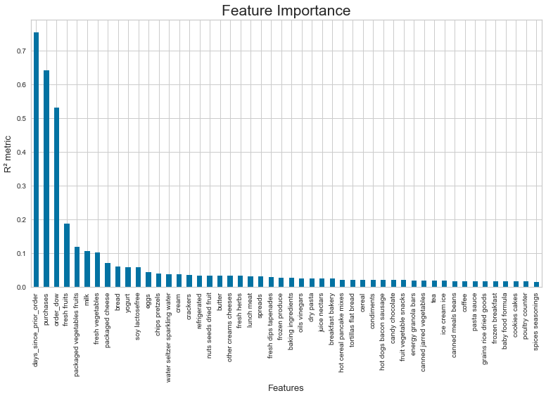

```python
feature_importance = pd.concat((df_scaled, pd.Series(km_labels, name='labels')), axis=1)
feature_importance = r2_variables(feature_importance, "labels").sort_values(ascending=False).drop(["labels"])
# 50 top features
feature_importance[0:50].to_frame().plot.bar(figsize=(13,7))
plt.title("Feature Importance", fontsize=21)
plt.legend().remove()
plt.xlabel("Features", fontsize=13)
plt.ylabel("R² metric", fontsize=13)
plt.show()
```

We have two different persepectives to be analyzed here: **purchase behavior** and **product types**.  
The purchase behavior variables seem hereby to be the most important in explaining the cluster compositions.

### 3.2. Basic Analysis

```python
df_clustered = clusters.copy()
```

```python
df_clustered["labels"] = df_clustered.labels + 1
```

```python
df_clustered.labels.value_counts()
```

```
4    30850
1    30416
3    23543
2    14109
Name: labels, dtype: int64
```

```python
df_clustered.groupby("labels").mean()
```

| labels | purchases | days_since_prior_order | order_dow | order_hour_of_day | air fresheners candles | asian foods | baby accessories | baby bath body care | baby food formula | bakery desserts | ... | spreads | tea | tofu meat alternatives | tortillas flat bread | trail mix snack mix | trash bags liners | vitamins supplements | water seltzer sparkling water | white wines | yogurt |
| --- | --- | --- | --- | --- | --- | --- | --- | --- | --- | --- | --- | --- | --- | --- | --- | --- | --- | --- | --- | --- | --- |
| 1 | 12.940229 | 9.684025 | 1.101495 | 13.476202 | 0.009797 | 0.083607 | 0.003321 | 0.003518 | 0.180990 | 0.018050 | ... | 0.149296 | 0.123356 | 0.065985 | 0.104978 | 0.020088 | 0.016176 | 0.021699 | 0.439506 | 0.013743 | 0.765978 |
| 2 | 51.294351 | 5.668779 | 2.804242 | 13.258592 | 0.018711 | 0.219576 | 0.014884 | 0.013963 | 0.673896 | 0.046566 | ... | 0.418740 | 0.397335 | 0.171451 | 0.270749 | 0.052803 | 0.036076 | 0.074137 | 1.145368 | 0.035297 | 2.204692 |
| 3 | 7.389670 | 27.040493 | 2.716397 | 13.654223 | 0.009515 | 0.077518 | 0.002379 | 0.002676 | 0.117317 | 0.014187 | ... | 0.126237 | 0.098458 | 0.056620 | 0.084399 | 0.014399 | 0.017542 | 0.017542 | 0.360362 | 0.011638 | 0.545512 |
| 4 | 12.868428 | 9.151281 | 4.408801 | 13.602903 | 0.013387 | 0.082723 | 0.003987 | 0.004149 | 0.163922 | 0.019935 | ... | 0.134846 | 0.117958 | 0.063857 | 0.087618 | 0.015494 | 0.017569 | 0.023241 | 0.423890 | 0.019870 | 0.675754 |

4 rows × 138 columns

### 3.3. Purchase Behavior

```python
pb = df_clustered[["purchases", "days_since_prior_order", "order_dow", "order_hour_of_day", "labels"]]
```

### Cluster performance per variables compared to overall population

```python
pb_means = pb.groupby("labels").mean()
pb_means = pb_means.append(pb.drop("labels", axis=1).mean(), ignore_index=True)
pb_means["Cluster"] = ["Cluster 1", "Cluster 2", "Cluster 3", "Cluster 4", "Average"]
```

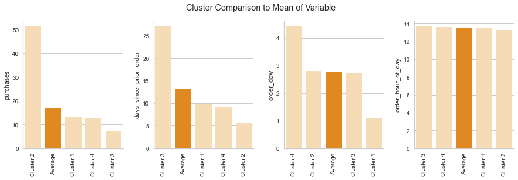

```python
#ceil(len(features) / 3
fig, axes = plt.subplots(1,4 , figsize=(15, 4))

metric_features = pb_means.columns.to_list()
for ax, feat in zip(axes.flatten(), metric_features):
    sns.barplot(x="Cluster", y = feat, data=pb_means.sort_values(feat, ascending=False),
                palette=["navajowhite" if x!='Average' else 'darkorange' for x in pb_means.sort_values(
                feat, ascending=False).Cluster],
                ax=ax).set(xlabel='')
    sns.despine(right=True)

title = "Cluster Comparison to Mean of Variable"
plt.suptitle(title)

# Rotating X-axis labels
axes.flatten()[0].tick_params(axis='x', labelrotation = 90)
axes.flatten()[1].tick_params(axis='x', labelrotation = 90)
axes.flatten()[2].tick_params(axis='x', labelrotation = 90)
axes.flatten()[3].tick_params(axis='x', labelrotation = 90)
plt.subplots_adjust(wspace=0.3, hspace=0.7)

plt.show()
```

### Box plotting the purchase behavior

```python
def box_plot(df, x, y, title):

    # set figure parameters
    plt.rcParams['figure.figsize'] = (12,4)

    # box plots
    plt.subplot(1,2,1)
    sns.boxplot(data=df, x=x, y=y, palette='Set1_r', showfliers=False)
    plt.title(title, fontsize=14)

    plt.tight_layout()
    plt.show()
```

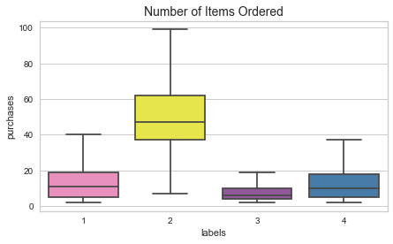

```python
box_plot(df_clustered,'labels','purchases','Number of Items Ordered')
```

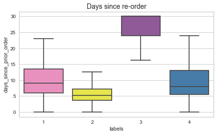

```python
box_plot(df_clustered,'labels','days_since_prior_order','Days since re-order')
```

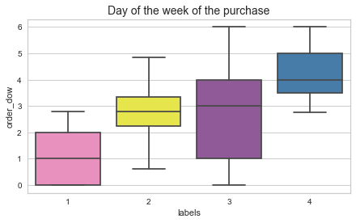

```python
box_plot(df_clustered,'labels','order_dow','Day of the week of the purchase')
```

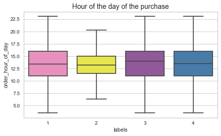

```python
box_plot(df_clustered,'labels','order_hour_of_day','Hour of the day of the purchase')
```

### Kernel Density Estimate plots for purchase behaviour

**What are Kernel Density Estimate plots?**  
KDE Plot described as Kernel Density Estimate is used for visualizing the Probability Density of a continuous variable. It depicts the probability density at different values in a continuous variable.

```python
my_data = df_clustered.sample(frac=0.2)
print("--- Shape:\n",my_data.shape)
my_data.head()
```

```
--- Shape:
 (19784, 139)
```

|  | purchases | days_since_prior_order | order_dow | order_hour_of_day | air fresheners candles | asian foods | baby accessories | baby bath body care | baby food formula | bakery desserts | ... | tea | tofu meat alternatives | tortillas flat bread | trail mix snack mix | trash bags liners | vitamins supplements | water seltzer sparkling water | white wines | yogurt | labels |
| --- | --- | --- | --- | --- | --- | --- | --- | --- | --- | --- | --- | --- | --- | --- | --- | --- | --- | --- | --- | --- | --- |
| 17116 | 3 | 14.0 | 1.0 | 12.0 | 0 | 0 | 0 | 0 | 0 | 0 | ... | 0 | 0 | 0 | 0 | 0 | 0 | 1 | 0 | 0 | 1 |
| 75091 | 22 | 9.0 | 3.0 | 17.0 | 0 | 0 | 0 | 0 | 0 | 0 | ... | 1 | 0 | 0 | 0 | 0 | 0 | 0 | 0 | 3 | 4 |
| 90502 | 5 | 27.0 | 2.0 | 13.0 | 0 | 0 | 0 | 0 | 0 | 0 | ... | 0 | 0 | 0 | 0 | 0 | 0 | 0 | 0 | 0 | 3 |
| 70631 | 5 | 4.0 | 6.0 | 13.0 | 0 | 0 | 0 | 0 | 0 | 0 | ... | 0 | 0 | 0 | 0 | 0 | 0 | 0 | 1 | 0 | 4 |
| 86768 | 12 | 6.0 | 6.0 | 9.0 | 0 | 0 | 0 | 0 | 0 | 0 | ... | 0 | 1 | 1 | 0 | 0 | 0 | 0 | 0 | 0 | 4 |

5 rows × 139 columns

### Purchase behaviour (Purchase vs. all)

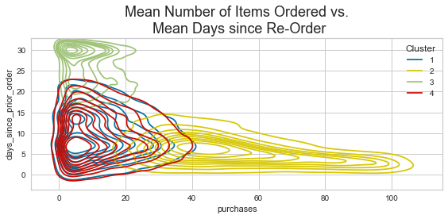

```python
# set figure size
plt.rcParams['figure.figsize'] = (8,4)

# kde plots
sns.kdeplot(my_data[my_data.labels==1].purchases, my_data[my_data.labels==1].days_since_prior_order, shade=False, shade_lowest=False, color='b', label='1')
sns.kdeplot(my_data[my_data.labels==2].purchases, my_data[my_data.labels==2].days_since_prior_order, shade=False, shade_lowest=False, color='y', label='2')
sns.kdeplot(my_data[my_data.labels==3].purchases, my_data[my_data.labels==3].days_since_prior_order, shade=False, shade_lowest=False, color='g', label='3')
sns.kdeplot(my_data[my_data.labels==4].purchases, my_data[my_data.labels==4].days_since_prior_order, shade=False, shade_lowest=False, color='r', label='4')
# plot labeling options
plt.legend(title='Cluster')
plt.title('Mean Number of Items Ordered vs.\n Mean Days since Re-Order', fontsize=18)

plt.tight_layout()
plt.show()
```

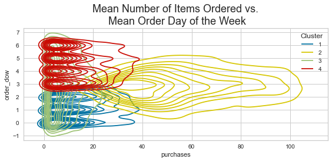

```python
# set figure size
plt.rcParams['figure.figsize'] = (8,4)

# kde plots
sns.kdeplot(my_data[my_data.labels==1].purchases, my_data[my_data.labels==1].order_dow, shade=False, shade_lowest=False, color='b', label='1')
sns.kdeplot(my_data[my_data.labels==2].purchases, my_data[my_data.labels==2].order_dow, shade=False, shade_lowest=False, color='y', label='2')
sns.kdeplot(my_data[my_data.labels==3].purchases, my_data[my_data.labels==3].order_dow, shade=False, shade_lowest=False, color='g', label='3')
sns.kdeplot(my_data[my_data.labels==4].purchases, my_data[my_data.labels==4].order_dow, shade=False, shade_lowest=False, color='r', label='4')

# plot labeling options
plt.legend(title='Cluster')
plt.title('Mean Number of Items Ordered vs.\n Mean Order Day of the Week', fontsize=18)

plt.tight_layout()
plt.show()
```

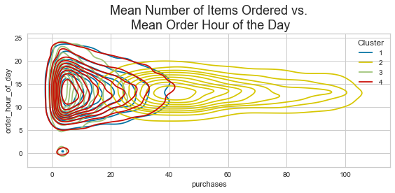

```python
# set figure size
plt.rcParams['figure.figsize'] = (8,4)

# kde plots
sns.kdeplot(my_data[my_data.labels==1].purchases, my_data[my_data.labels==1].order_hour_of_day, shade=False, shade_lowest=False, color='b', label='1')
sns.kdeplot(my_data[my_data.labels==2].purchases, my_data[my_data.labels==2].order_hour_of_day, shade=False, shade_lowest=False, color='y', label='2')
sns.kdeplot(my_data[my_data.labels==3].purchases, my_data[my_data.labels==3].order_hour_of_day, shade=False, shade_lowest=False, color='g', label='3')
sns.kdeplot(my_data[my_data.labels==4].purchases, my_data[my_data.labels==4].order_hour_of_day, shade=False, shade_lowest=False, color='r', label='4')


# plot labeling options
plt.legend(title='Cluster')
plt.title('Mean Number of Items Ordered vs.\n Mean Order Hour of the Day', fontsize=18)

plt.tight_layout()
plt.show()
```

### Purchase behaviour (Days since re-order vs. all)

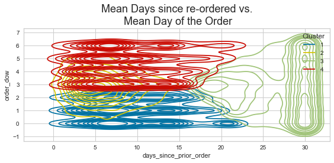

```python
# set figure size
plt.rcParams['figure.figsize'] = (8,4)

# kde plots
sns.kdeplot(my_data[my_data.labels==1].days_since_prior_order, my_data[my_data.labels==1].order_dow, shade=False, shade_lowest=False, color='b', label='1')
sns.kdeplot(my_data[my_data.labels==2].days_since_prior_order, my_data[my_data.labels==2].order_dow, shade=False, shade_lowest=False, color='y', label='2')
sns.kdeplot(my_data[my_data.labels==3].days_since_prior_order, my_data[my_data.labels==3].order_dow, shade=False, shade_lowest=False, color='g', label='3')
sns.kdeplot(my_data[my_data.labels==4].days_since_prior_order, my_data[my_data.labels==4].order_dow, shade=False, shade_lowest=False, color='r', label='4')

# plot labeling options
plt.legend(title='Cluster')
plt.title('Mean Days since re-ordered vs.\n Mean Day of the Order', fontsize=18)

plt.tight_layout()
plt.show()
```

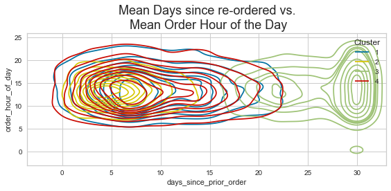

```python
# set figure size
plt.rcParams['figure.figsize'] = (8,4)

# kde plots
sns.kdeplot(my_data[my_data.labels==1].days_since_prior_order, my_data[my_data.labels==1].order_hour_of_day, shade=False, shade_lowest=False, color='b', label='1')
sns.kdeplot(my_data[my_data.labels==2].days_since_prior_order, my_data[my_data.labels==2].order_hour_of_day, shade=False, shade_lowest=False, color='y', label='2')
sns.kdeplot(my_data[my_data.labels==3].days_since_prior_order, my_data[my_data.labels==3].order_hour_of_day, shade=False, shade_lowest=False, color='g', label='3')
sns.kdeplot(my_data[my_data.labels==4].days_since_prior_order, my_data[my_data.labels==4].order_hour_of_day, shade=False, shade_lowest=False, color='r', label='4')

# plot labeling options
plt.legend(title='Cluster')
plt.title('Mean Days since re-ordered vs.\n Mean Order Hour of the Day', fontsize=18)

plt.tight_layout()
plt.show()
```

### 3.4. Analysis Based on Product Types

```python
product_types = df_clustered.loc[:,"air fresheners candles":]
```

```python
products_labels = product_types.groupby("labels").mean()
products_labels.head()
```

| labels | air fresheners candles | asian foods | baby accessories | baby bath body care | baby food formula | bakery desserts | baking ingredients | baking supplies decor | beauty | beers coolers | ... | spreads | tea | tofu meat alternatives | tortillas flat bread | trail mix snack mix | trash bags liners | vitamins supplements | water seltzer sparkling water | white wines | yogurt |
| --- | --- | --- | --- | --- | --- | --- | --- | --- | --- | --- | --- | --- | --- | --- | --- | --- | --- | --- | --- | --- | --- |
| 1 | 0.009797 | 0.083607 | 0.003321 | 0.003518 | 0.180990 | 0.018050 | 0.158371 | 0.010521 | 0.002992 | 0.020581 | ... | 0.149296 | 0.123356 | 0.065985 | 0.104978 | 0.020088 | 0.016176 | 0.021699 | 0.439506 | 0.013743 | 0.765978 |
| 2 | 0.018711 | 0.219576 | 0.014884 | 0.013963 | 0.673896 | 0.046566 | 0.452902 | 0.027996 | 0.006521 | 0.046283 | ... | 0.418740 | 0.397335 | 0.171451 | 0.270749 | 0.052803 | 0.036076 | 0.074137 | 1.145368 | 0.035297 | 2.204692 |
| 3 | 0.009515 | 0.077518 | 0.002379 | 0.002676 | 0.117317 | 0.014187 | 0.137153 | 0.011214 | 0.003058 | 0.017585 | ... | 0.126237 | 0.098458 | 0.056620 | 0.084399 | 0.014399 | 0.017542 | 0.017542 | 0.360362 | 0.011638 | 0.545512 |
| 4 | 0.013387 | 0.082723 | 0.003987 | 0.004149 | 0.163922 | 0.019935 | 0.163825 | 0.013355 | 0.003663 | 0.037828 | ... | 0.134846 | 0.117958 | 0.063857 | 0.087618 | 0.015494 | 0.017569 | 0.023241 | 0.423890 | 0.019870 | 0.675754 |

4 rows × 134 columns

```python
products_c1 = products_labels.iloc[[0]]
products_c2 = products_labels.iloc[[1]]
products_c3 = products_labels.iloc[[2]]
products_c4 = products_labels.iloc[[3]]
```

### Cluster performance per product types compared to overall population - Top 20

```python
top_20 = feature_importance[3:23].reset_index()["index"].to_list()
```

```python
pt_means = products_labels[top_20].append(product_types[top_20].mean(), ignore_index=True)
pt_means["Cluster"] = ["Cluster 1", "Cluster 2", "Cluster 3", "Cluster 4", "Average"]
pt_means
```

|  | fresh fruits | packaged vegetables fruits | milk | fresh vegetables | packaged cheese | bread | yogurt | soy lactosefree | eggs | chips pretzels | ... | cream | crackers | refrigerated | nuts seeds dried fruit | butter | other creams cheeses | fresh herbs | lunch meat | spreads | Cluster |
| --- | --- | --- | --- | --- | --- | --- | --- | --- | --- | --- | --- | --- | --- | --- | --- | --- | --- | --- | --- | --- | --- |
| 0 | 1.911560 | 0.940821 | 0.441248 | 1.833114 | 0.519628 | 0.296193 | 0.765978 | 0.322166 | 0.234153 | 0.377663 | ... | 0.160738 | 0.235928 | 0.291524 | 0.155379 | 0.122370 | 0.153998 | 0.192201 | 0.211599 | 0.149296 | Cluster 1 |
| 1 | 5.602311 | 2.527819 | 1.428096 | 4.762917 | 1.376143 | 0.852222 | 2.204692 | 0.937416 | 0.610461 | 0.969239 | ... | 0.486852 | 0.639237 | 0.834786 | 0.460770 | 0.362535 | 0.433766 | 0.537600 | 0.544688 | 0.418740 | Cluster 2 |
| 2 | 1.316442 | 0.704116 | 0.313681 | 1.418129 | 0.416217 | 0.235314 | 0.545512 | 0.254980 | 0.200102 | 0.322856 | ... | 0.115321 | 0.199762 | 0.224525 | 0.125175 | 0.112305 | 0.129550 | 0.152657 | 0.161279 | 0.126237 | Cluster 3 |
| 3 | 1.672707 | 0.824214 | 0.413258 | 1.603566 | 0.469627 | 0.279676 | 0.675754 | 0.300292 | 0.215494 | 0.358768 | ... | 0.155073 | 0.219870 | 0.290665 | 0.139449 | 0.122755 | 0.150308 | 0.180162 | 0.186029 | 0.134846 | Cluster 4 |
| 4 | 2.221850 | 1.074476 | 0.542914 | 2.080643 | 0.601589 | 0.355860 | 0.890576 | 0.387109 | 0.273904 | 0.443104 | ... | 0.194676 | 0.279838 | 0.352797 | 0.186781 | 0.154350 | 0.186933 | 0.228300 | 0.239158 | 0.177733 | Average |

5 rows × 21 columns

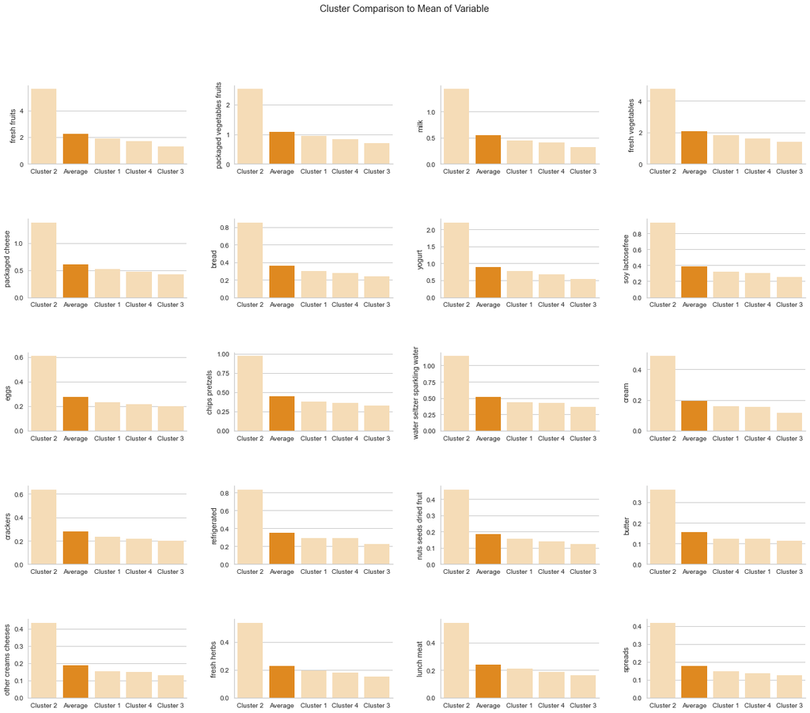

```python
#ceil(len(features) / 3
fig, axes = plt.subplots(5,4 , figsize=(21, 17))

metric_features = pt_means.columns.to_list()
for ax, feat in zip(axes.flatten(), metric_features):
    sns.barplot(x="Cluster", y = feat, data=pt_means.sort_values(feat, ascending=False),
                palette=["navajowhite" if x!='Average' else 'darkorange' for x in pt_means.sort_values(
                feat, ascending=False).Cluster],
                ax=ax).set(xlabel='')
    sns.despine(right=True)

title = "Cluster Comparison to Mean of Variable"
plt.suptitle(title)


plt.subplots_adjust(wspace=0.3, hspace=0.7)

plt.show()
```

### Top 20 Products per Cluster

```python
products_c1.T.sort_values(by=[1],ascending=False)[:20]
```

| labels | 1 |
| --- | --- |
| fresh fruits | 1.911560 |
| fresh vegetables | 1.833114 |
| packaged vegetables fruits | 0.940821 |
| yogurt | 0.765978 |
| packaged cheese | 0.519628 |
| milk | 0.441248 |
| water seltzer sparkling water | 0.439506 |
| chips pretzels | 0.377663 |
| soy lactosefree | 0.322166 |
| bread | 0.296193 |
| refrigerated | 0.291524 |
| frozen produce | 0.282680 |
| energy granola bars | 0.260060 |
| ice cream ice | 0.251414 |
| crackers | 0.235928 |
| eggs | 0.234153 |
| frozen meals | 0.219983 |
| lunch meat | 0.211599 |
| cereal | 0.201144 |
| fresh herbs | 0.192201 |

```python
products_c2.T.sort_values(by=[2],ascending=False)[:20]
```

| labels | 2 |
| --- | --- |
| fresh fruits | 5.602311 |
| fresh vegetables | 4.762917 |
| packaged vegetables fruits | 2.527819 |
| yogurt | 2.204692 |
| milk | 1.428096 |
| packaged cheese | 1.376143 |
| water seltzer sparkling water | 1.145368 |
| chips pretzels | 0.969239 |
| soy lactosefree | 0.937416 |
| bread | 0.852222 |
| refrigerated | 0.834786 |
| energy granola bars | 0.682260 |
| baby food formula | 0.673896 |
| frozen produce | 0.667163 |
| crackers | 0.639237 |
| eggs | 0.610461 |
| ice cream ice | 0.602523 |
| lunch meat | 0.544688 |
| fresh herbs | 0.537600 |
| cereal | 0.497413 |

```python
products_c3.T.sort_values(by=[3],ascending=False)[:20]
```

| labels | 3 |
| --- | --- |
| fresh vegetables | 1.418129 |
| fresh fruits | 1.316442 |
| packaged vegetables fruits | 0.704116 |
| yogurt | 0.545512 |
| packaged cheese | 0.416217 |
| water seltzer sparkling water | 0.360362 |
| chips pretzels | 0.322856 |
| milk | 0.313681 |
| soy lactosefree | 0.254980 |
| bread | 0.235314 |
| frozen produce | 0.234719 |
| ice cream ice | 0.227244 |
| refrigerated | 0.224525 |
| eggs | 0.200102 |
| frozen meals | 0.199932 |
| crackers | 0.199762 |
| energy granola bars | 0.176868 |
| soft drinks | 0.174022 |
| cereal | 0.172111 |
| soup broth bouillon | 0.169944 |

```python
products_c4.T.sort_values(by=[4],ascending=False)[:20]
```

| labels | 4 |
| --- | --- |
| fresh fruits | 1.672707 |
| fresh vegetables | 1.603566 |
| packaged vegetables fruits | 0.824214 |
| yogurt | 0.675754 |
| packaged cheese | 0.469627 |
| water seltzer sparkling water | 0.423890 |
| milk | 0.413258 |
| chips pretzels | 0.358768 |
| soy lactosefree | 0.300292 |
| refrigerated | 0.290665 |
| ice cream ice | 0.285024 |
| bread | 0.279676 |
| frozen produce | 0.253128 |
| crackers | 0.219870 |
| eggs | 0.215494 |
| frozen meals | 0.212415 |
| soft drinks | 0.207682 |
| energy granola bars | 0.199870 |
| cereal | 0.186645 |
| lunch meat | 0.186029 |

## 4. MBA per Cluster

### 4.1. Transform and shape dataframe to re-apply MBA on selected cluster

```python
user_labels = pd.concat((df_clustered.labels, users_df.reset_index().user_id), axis=1)
```

```python
mba_merge = user_labels.merge(orders[["order_id", "user_id"]], how="left", on="user_id")
mba_merge = mba_merge.merge(order_prod, how="left", on="order_id").drop("user_id", axis=1)
mba_merge = pd.merge(mba_merge, products, how='left', on='product_id').\
            drop(["product_id", "department_id"], axis=1)
```

```python
# prepared table for MBA
mba_merge.head()
```

|  | labels | order_id | product_name |
| --- | --- | --- | --- |
| 0 | 4 | 1901567 | fresh fruits |
| 1 | 4 | 1901567 | popcorn jerky |
| 2 | 4 | 1901567 | lunch meat |
| 3 | 4 | 1901567 | packaged cheese |
| 4 | 4 | 1901567 | prepared soups salads |

### Dividing the df based on their cluster labels

```python
cluster_one = mba_merge.loc[mba_merge.labels == 1].drop("labels", axis=1)
cluster_two = mba_merge.loc[mba_merge.labels == 2].drop("labels", axis=1)
cluster_three = mba_merge.loc[mba_merge.labels == 3].drop("labels", axis=1)
cluster_four = mba_merge.loc[mba_merge.labels == 4].drop("labels", axis=1)
```

```python
cluster_four.head()
```

|  | order_id | product_name |
| --- | --- | --- |
| 0 | 1901567 | fresh fruits |
| 1 | 1901567 | popcorn jerky |
| 2 | 1901567 | lunch meat |
| 3 | 1901567 | packaged cheese |
| 4 | 1901567 | prepared soups salads |

```python
# create function to perform MBA for each cluster based df
def create_pivot(df):
    pt = df.pivot_table(index='order_id', columns='product_name',
                        aggfunc=lambda x: 1 if len(x)>0 else 0).fillna(0)
    return pt
```

```python
pt_one = create_pivot(cluster_one)
pt_one.shape
```

```
(50999, 134)
```

```python
pt_two = create_pivot(cluster_two)
pt_two.shape
```

```
(59931, 134)
```

```python
pt_three = create_pivot(cluster_three)
pt_three.shape
```

```
(31801, 134)
```

```python
pt_four = create_pivot(cluster_four)
pt_four.shape
```

```
(50914, 134)
```

#### Check if equal with inital df length

(new orders not included (kicked them out) therefore not equal to 200k here)

```python
pt_one.shape[0] + pt_two.shape[0] + pt_three.shape[0] + pt_four.shape[0]
```

```
193645
```

```python
user_labels.merge(orders[["order_id", "user_id"]], how="left", on="user_id").shape[0]
```

```
193645
```

## 4.2. MBA for Cluster 2 - Frequent shoppers

Most profitable buyers

```python
pt_two.head()
```

| product_name order_id | air fresheners candles | asian foods | baby accessories | baby bath body care | baby food formula | bakery desserts | baking ingredients | baking supplies decor | beauty | beers coolers | ... | spreads | tea | tofu meat alternatives | tortillas flat bread | trail mix snack mix | trash bags liners | vitamins supplements | water seltzer sparkling water | white wines | yogurt |
| --- | --- | --- | --- | --- | --- | --- | --- | --- | --- | --- | --- | --- | --- | --- | --- | --- | --- | --- | --- | --- | --- |
| 28 | 0.0 | 0.0 | 0.0 | 0.0 | 0.0 | 0.0 | 0.0 | 0.0 | 0.0 | 0.0 | ... | 1.0 | 0.0 | 0.0 | 0.0 | 0.0 | 0.0 | 0.0 | 0.0 | 0.0 | 1.0 |
| 56 | 0.0 | 0.0 | 0.0 | 0.0 | 0.0 | 0.0 | 0.0 | 0.0 | 0.0 | 0.0 | ... | 0.0 | 0.0 | 0.0 | 0.0 | 0.0 | 0.0 | 0.0 | 0.0 | 0.0 | 0.0 |
| 122 | 0.0 | 0.0 | 0.0 | 0.0 | 0.0 | 0.0 | 0.0 | 0.0 | 0.0 | 0.0 | ... | 0.0 | 0.0 | 0.0 | 0.0 | 0.0 | 0.0 | 0.0 | 0.0 | 0.0 | 0.0 |
| 192 | 0.0 | 0.0 | 0.0 | 0.0 | 0.0 | 0.0 | 0.0 | 0.0 | 0.0 | 0.0 | ... | 0.0 | 0.0 | 0.0 | 0.0 | 0.0 | 0.0 | 0.0 | 0.0 | 0.0 | 1.0 |
| 227 | 0.0 | 0.0 | 0.0 | 0.0 | 0.0 | 0.0 | 0.0 | 0.0 | 0.0 | 0.0 | ... | 1.0 | 0.0 | 0.0 | 0.0 | 0.0 | 0.0 | 0.0 | 0.0 | 0.0 | 0.0 |

5 rows × 134 columns

### 4.2.1 Support

```python
# Apply the APRIORI algorithm to get frequent itemsets
frequent_itemsets_freq = apriori(pt_two, min_support=0.05, use_colnames=True)
frequent_itemsets_freq.head()
```

|  | support | itemsets |
| --- | --- | --- |
| 0 | 0.062739 | (baby food formula) |
| 1 | 0.081677 | (baking ingredients) |
| 2 | 0.177454 | (bread) |
| 3 | 0.072884 | (breakfast bakery) |
| 4 | 0.080376 | (butter) |

### 4.2.2 Support itemsets - Frequent shoppers

```python
frequent_itemsets_freq.sort_values(by='support', ascending=False).reset_index(drop=True).head(20)
```

|  | support | itemsets |
| --- | --- | --- |
| 0 | 0.608833 | (fresh fruits) |
| 1 | 0.466370 | (fresh vegetables) |
| 2 | 0.390599 | (packaged vegetables fruits) |
| 3 | 0.346448 | (fresh vegetables, fresh fruits) |
| 4 | 0.300395 | (fresh fruits, packaged vegetables fruits) |
| 5 | 0.289433 | (yogurt) |
| 6 | 0.288482 | (milk) |
| 7 | 0.252023 | (fresh vegetables, packaged vegetables fruits) |
| 8 | 0.240193 | (packaged cheese) |
| 9 | 0.215781 | (fresh fruits, yogurt) |
| 10 | 0.206404 | (fresh fruits, milk) |
| 11 | 0.206220 | (fresh vegetables, fresh fruits, packaged vege... |
| 12 | 0.191287 | (water seltzer sparkling water) |
| 13 | 0.184946 | (soy lactosefree) |
| 14 | 0.177454 | (bread) |
| 15 | 0.174067 | (packaged cheese, fresh fruits) |
| 16 | 0.167676 | (chips pretzels) |
| 17 | 0.158399 | (fresh vegetables, yogurt) |
| 18 | 0.150323 | (fresh vegetables, milk) |
| 19 | 0.144399 | (yogurt, packaged vegetables fruits) |

```python
# Complementary and substitute products
rulesLift2_freq = association_rules(frequent_itemsets_freq, metric="lift", min_threshold=0.01)
```

```python
rulesLift2_freq['length_ant'] = rulesLift2_freq['antecedents'].apply(lambda x: len(x))
rulesLift2_freq['length_cons'] = rulesLift2_freq['consequents'].apply(lambda x: len(x))
```

### 4.2.3 Complementary itemsets for frequent shoppers

```python
# Complementary products
rulesLift2_freq.sort_values(by='lift', ascending=False, inplace=True)
rulesLift2_freq_com = rulesLift2_freq[(rulesLift2_freq['length_ant'] <= 1) &
                                    (rulesLift2_freq['length_cons'] <= 1) &
                                    (rulesLift2_freq['conviction'] > 1.3)].sort_values(
    by=['lift','conviction'], ascending = False).reset_index(drop=True)
rulesLift2_freq_com.iloc[:,:9]
```

|  | antecedents | consequents | antecedent support | consequent support | support | confidence | lift | leverage | conviction |
| --- | --- | --- | --- | --- | --- | --- | --- | --- | --- |
| 0 | (fresh herbs) | (fresh vegetables) | 0.100098 | 0.466370 | 0.084480 | 0.843974 | 1.809667 | 0.037798 | 3.420137 |
| 1 | (canned jarred vegetables) | (fresh vegetables) | 0.070715 | 0.466370 | 0.055330 | 0.782445 | 1.677735 | 0.022351 | 2.452847 |
| 2 | (canned meals beans) | (fresh vegetables) | 0.067644 | 0.466370 | 0.050141 | 0.741243 | 1.589390 | 0.018594 | 2.062285 |
| 3 | (soup broth bouillon) | (fresh vegetables) | 0.076188 | 0.466370 | 0.053378 | 0.700613 | 1.502270 | 0.017846 | 1.782411 |
| 4 | (fresh herbs) | (packaged vegetables fruits) | 0.100098 | 0.390599 | 0.058234 | 0.581764 | 1.489413 | 0.019135 | 1.457073 |
| 5 | (dry pasta) | (fresh vegetables) | 0.073601 | 0.466370 | 0.051042 | 0.693494 | 1.487004 | 0.016717 | 1.741008 |
| 6 | (fresh dips tapenades) | (packaged vegetables fruits) | 0.098697 | 0.390599 | 0.056331 | 0.570752 | 1.461223 | 0.017781 | 1.419695 |
| 7 | (frozen produce) | (packaged vegetables fruits) | 0.121323 | 0.390599 | 0.068362 | 0.563471 | 1.442582 | 0.020973 | 1.396016 |
| 8 | (lunch meat) | (packaged vegetables fruits) | 0.107357 | 0.390599 | 0.058451 | 0.544451 | 1.393888 | 0.016517 | 1.337729 |
| 9 | (packaged vegetables fruits) | (fresh vegetables) | 0.390599 | 0.466370 | 0.252023 | 0.645222 | 1.383499 | 0.069860 | 1.504124 |
| 10 | (fresh vegetables) | (packaged vegetables fruits) | 0.466370 | 0.390599 | 0.252023 | 0.540394 | 1.383499 | 0.069860 | 1.325919 |
| 11 | (frozen produce) | (fresh vegetables) | 0.121323 | 0.466370 | 0.078257 | 0.645028 | 1.383084 | 0.021675 | 1.503303 |
| 12 | (butter) | (fresh vegetables) | 0.080376 | 0.466370 | 0.050758 | 0.631513 | 1.354105 | 0.013274 | 1.448168 |
| 13 | (eggs) | (fresh vegetables) | 0.139794 | 0.466370 | 0.088235 | 0.631177 | 1.353383 | 0.023039 | 1.446846 |
| 14 | (other creams cheeses) | (fresh vegetables) | 0.092123 | 0.466370 | 0.056715 | 0.615649 | 1.320089 | 0.013752 | 1.388394 |
| 15 | (lunch meat) | (fresh vegetables) | 0.107357 | 0.466370 | 0.064958 | 0.605067 | 1.297398 | 0.014890 | 1.351192 |
| 16 | (fresh dips tapenades) | (fresh vegetables) | 0.098697 | 0.466370 | 0.059352 | 0.601352 | 1.289433 | 0.013322 | 1.338602 |
| 17 | (packaged cheese) | (fresh vegetables) | 0.240193 | 0.466370 | 0.143949 | 0.599305 | 1.285044 | 0.031930 | 1.331763 |
| 18 | (fresh herbs) | (fresh fruits) | 0.100098 | 0.608833 | 0.077005 | 0.769295 | 1.263555 | 0.016062 | 1.695526 |
| 19 | (packaged vegetables fruits) | (fresh fruits) | 0.390599 | 0.608833 | 0.300395 | 0.769063 | 1.263175 | 0.062586 | 1.693825 |
| 20 | (canned meals beans) | (fresh fruits) | 0.067644 | 0.608833 | 0.051943 | 0.767884 | 1.261237 | 0.010759 | 1.685217 |
| 21 | (frozen produce) | (fresh fruits) | 0.121323 | 0.608833 | 0.092223 | 0.760143 | 1.248524 | 0.018357 | 1.630832 |
| 22 | (fresh dips tapenades) | (fresh fruits) | 0.098697 | 0.608833 | 0.074886 | 0.758749 | 1.246234 | 0.014796 | 1.621408 |
| 23 | (lunch meat) | (fresh fruits) | 0.107357 | 0.608833 | 0.080776 | 0.752409 | 1.235821 | 0.015414 | 1.579890 |
| 24 | (yogurt) | (fresh fruits) | 0.289433 | 0.608833 | 0.215781 | 0.745532 | 1.224525 | 0.039565 | 1.537194 |
| 25 | (fresh vegetables) | (fresh fruits) | 0.466370 | 0.608833 | 0.346448 | 0.742862 | 1.220140 | 0.062507 | 1.521233 |
| 26 | (bread) | (fresh fruits) | 0.177454 | 0.608833 | 0.131368 | 0.740291 | 1.215918 | 0.023328 | 1.506175 |
| 27 | (eggs) | (fresh fruits) | 0.139794 | 0.608833 | 0.102952 | 0.736453 | 1.209613 | 0.017840 | 1.484236 |
| 28 | (nuts seeds dried fruit) | (fresh fruits) | 0.089853 | 0.608833 | 0.065609 | 0.730176 | 1.199304 | 0.010903 | 1.449712 |
| 29 | (dry pasta) | (fresh fruits) | 0.073601 | 0.608833 | 0.053712 | 0.729766 | 1.198631 | 0.008901 | 1.447513 |
| 30 | (soy lactosefree) | (fresh fruits) | 0.184946 | 0.608833 | 0.134471 | 0.727084 | 1.194225 | 0.021870 | 1.433286 |
| 31 | (energy granola bars) | (fresh fruits) | 0.094359 | 0.608833 | 0.068479 | 0.725729 | 1.192000 | 0.011030 | 1.426207 |
| 32 | (packaged cheese) | (fresh fruits) | 0.240193 | 0.608833 | 0.174067 | 0.724696 | 1.190303 | 0.027829 | 1.420853 |
| 33 | (butter) | (fresh fruits) | 0.080376 | 0.608833 | 0.058117 | 0.723064 | 1.187622 | 0.009181 | 1.412481 |
| 34 | (spreads) | (fresh fruits) | 0.084047 | 0.608833 | 0.060553 | 0.720469 | 1.183359 | 0.009383 | 1.399365 |
| 35 | (breakfast bakery) | (fresh fruits) | 0.072884 | 0.608833 | 0.052510 | 0.720467 | 1.183356 | 0.008136 | 1.399357 |
| 36 | (canned jarred vegetables) | (fresh fruits) | 0.070715 | 0.608833 | 0.050942 | 0.720387 | 1.183225 | 0.007888 | 1.398957 |
| 37 | (hot dogs bacon sausage) | (fresh fruits) | 0.080192 | 0.608833 | 0.057383 | 0.715564 | 1.175303 | 0.008559 | 1.375235 |
| 38 | (milk) | (fresh fruits) | 0.288482 | 0.608833 | 0.206404 | 0.715484 | 1.175172 | 0.030767 | 1.374848 |
| 39 | (cereal) | (fresh fruits) | 0.088986 | 0.608833 | 0.063573 | 0.714420 | 1.173424 | 0.009396 | 1.369725 |
| 40 | (crackers) | (fresh fruits) | 0.118837 | 0.608833 | 0.084664 | 0.712440 | 1.170173 | 0.012312 | 1.360297 |
| 41 | (other creams cheeses) | (fresh fruits) | 0.092123 | 0.608833 | 0.064474 | 0.699873 | 1.149531 | 0.008387 | 1.303338 |

### 4.2.4 Heatmap - Complementary itemsets for frequent shoppers

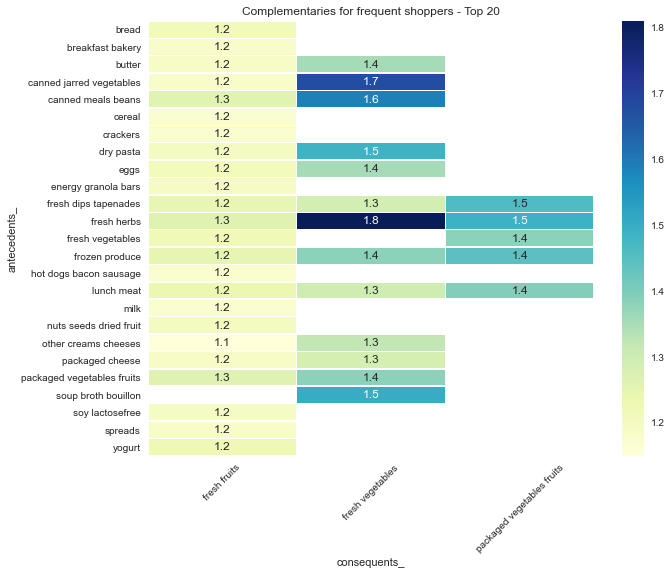

```python
# Import seaborn under its standard alias
import seaborn as sns

# Replace frozen sets with strings
rulesLift2_freq_com['antecedents_'] = rulesLift2_freq_com['antecedents'].apply(lambda a: ','.join(list(a)))
rulesLift2_freq_com['consequents_'] = rulesLift2_freq_com['consequents'].apply(lambda a: ','.join(list(a)))


# Transform the DataFrame of rules into a matrix using the lift metric
pivot = rulesLift2_freq_com[rulesLift2_freq_com['length_ant']==1].pivot(index = 'antecedents_',
                    columns = 'consequents_', values= 'lift')

# Generate a heatmap with annotations on and the colorbar off
fig, ax = plt.subplots(figsize=(10,8))
sns.heatmap(pivot, annot = True,linewidths=.5,ax=ax, cmap="YlGnBu").set_title("Complementaries for frequent shoppers - Top 20")
plt.yticks(rotation=0)
plt.xticks(rotation=45)
plt.savefig('Freq_coms_heatmap.png',bbox_inches='tight',dpi=250, transparent=True)
plt.show()
```

```python
# Function to convert rules to coordinates.
def rules_to_coordinates(rules):
    rules['antecedent'] = rules['antecedents'].apply(lambda antecedent: list(antecedent)[0])
    rules['consequent'] = rules['consequents'].apply(lambda consequent: list(consequent)[0])
    rules['rule'] = rules.index
    return rules[['antecedent','consequent','rule']]
```

```python
coords = rules_to_coordinates(rulesLift2_freq_com.iloc[:,:9])
```

```python
coords
```

|  | antecedent | consequent | rule |
| --- | --- | --- | --- |
| 0 | fresh herbs | fresh vegetables | 0 |
| 1 | canned jarred vegetables | fresh vegetables | 1 |
| 2 | canned meals beans | fresh vegetables | 2 |
| 3 | soup broth bouillon | fresh vegetables | 3 |
| 4 | fresh herbs | packaged vegetables fruits | 4 |
| 5 | dry pasta | fresh vegetables | 5 |
| 6 | fresh dips tapenades | packaged vegetables fruits | 6 |
| 7 | frozen produce | packaged vegetables fruits | 7 |
| 8 | lunch meat | packaged vegetables fruits | 8 |
| 9 | packaged vegetables fruits | fresh vegetables | 9 |
| 10 | fresh vegetables | packaged vegetables fruits | 10 |
| 11 | frozen produce | fresh vegetables | 11 |
| 12 | butter | fresh vegetables | 12 |
| 13 | eggs | fresh vegetables | 13 |
| 14 | other creams cheeses | fresh vegetables | 14 |
| 15 | lunch meat | fresh vegetables | 15 |
| 16 | fresh dips tapenades | fresh vegetables | 16 |
| 17 | packaged cheese | fresh vegetables | 17 |
| 18 | fresh herbs | fresh fruits | 18 |
| 19 | packaged vegetables fruits | fresh fruits | 19 |
| 20 | canned meals beans | fresh fruits | 20 |
| 21 | frozen produce | fresh fruits | 21 |
| 22 | fresh dips tapenades | fresh fruits | 22 |
| 23 | lunch meat | fresh fruits | 23 |
| 24 | yogurt | fresh fruits | 24 |
| 25 | fresh vegetables | fresh fruits | 25 |
| 26 | bread | fresh fruits | 26 |
| 27 | eggs | fresh fruits | 27 |
| 28 | nuts seeds dried fruit | fresh fruits | 28 |
| 29 | dry pasta | fresh fruits | 29 |
| 30 | soy lactosefree | fresh fruits | 30 |
| 31 | energy granola bars | fresh fruits | 31 |
| 32 | packaged cheese | fresh fruits | 32 |
| 33 | butter | fresh fruits | 33 |
| 34 | spreads | fresh fruits | 34 |
| 35 | breakfast bakery | fresh fruits | 35 |
| 36 | canned jarred vegetables | fresh fruits | 36 |
| 37 | hot dogs bacon sausage | fresh fruits | 37 |
| 38 | milk | fresh fruits | 38 |
| 39 | cereal | fresh fruits | 39 |
| 40 | crackers | fresh fruits | 40 |
| 41 | other creams cheeses | fresh fruits | 41 |

### 4.2.6 Parallel Coordinates Graph

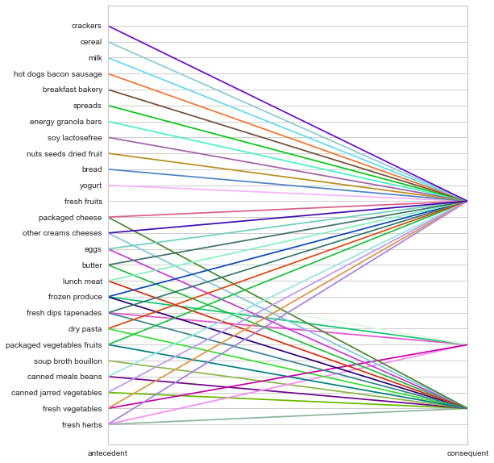

```python
plt.figure(figsize=(8,10))
pd.plotting.parallel_coordinates(coords, 'rule')
plt.legend([])
plt.grid(True)
plt.savefig('Freq_coms_coordination.png',bbox_inches='tight',dpi=250, transparent=True)
plt.show()
```

### 4.2.7 Substitute itemsets for frequent shoppers

```python
# Apply the APRIORI algorithm to get frequent itemsets
frequent_itemsets_freq = apriori(pt_two, min_support=0.025, use_colnames=True)
frequent_itemsets_freq.head()
```

|  | support | itemsets |
| --- | --- | --- |
| 0 | 0.043333 | (asian foods) |
| 1 | 0.062739 | (baby food formula) |
| 2 | 0.081677 | (baking ingredients) |
| 3 | 0.177454 | (bread) |
| 4 | 0.072884 | (breakfast bakery) |

```python
# Complementary and substitute products
rulesLift2_freq = association_rules(frequent_itemsets_freq, metric="lift", min_threshold=0.01)
```

```python
rulesLift2_freq['length_ant'] = rulesLift2_freq['antecedents'].apply(lambda x: len(x))
rulesLift2_freq['length_cons'] = rulesLift2_freq['consequents'].apply(lambda x: len(x))
```

```python
# Substitue products
rulesLift2_freq.sort_values(by='lift', ascending=False, inplace=True)
rulesLift2_freq_sub = rulesLift2_freq[(rulesLift2_freq['length_ant'] <= 1) &
                                    (rulesLift2_freq['length_cons'] <= 1) &
                                    (rulesLift2_freq['lift'] < 1)].sort_values(
    by=['lift','conviction'], ascending = True).reset_index(drop=True)
rulesLift2_freq_sub.iloc[:,:9]
```

|  | antecedents | consequents | antecedent support | consequent support | support | confidence | lift | leverage | conviction |
| --- | --- | --- | --- | --- | --- | --- | --- | --- | --- |
| 0 | (soft drinks) | (fresh fruits) | 0.072734 | 0.608833 | 0.037226 | 0.511815 | 0.840648 | -0.007057 | 0.801266 |
| 1 | (fresh fruits) | (soft drinks) | 0.608833 | 0.072734 | 0.037226 | 0.061143 | 0.840648 | -0.007057 | 0.987655 |
| 2 | (candy chocolate) | (fresh vegetables) | 0.076321 | 0.466370 | 0.032921 | 0.431351 | 0.924912 | -0.002673 | 0.938418 |
| 3 | (fresh vegetables) | (candy chocolate) | 0.466370 | 0.076321 | 0.032921 | 0.070590 | 0.924912 | -0.002673 | 0.993834 |
| 4 | (tea) | (fresh vegetables) | 0.063940 | 0.466370 | 0.027632 | 0.432150 | 0.926626 | -0.002188 | 0.939739 |
| 5 | (fresh vegetables) | (tea) | 0.466370 | 0.063940 | 0.027632 | 0.059249 | 0.926626 | -0.002188 | 0.995013 |
| 6 | (paper goods) | (fresh fruits) | 0.053395 | 0.608833 | 0.030302 | 0.567500 | 0.932110 | -0.002207 | 0.904431 |
| 7 | (fresh fruits) | (paper goods) | 0.608833 | 0.053395 | 0.030302 | 0.049770 | 0.932110 | -0.002207 | 0.996185 |
| 8 | (cookies cakes) | (fresh vegetables) | 0.060586 | 0.466370 | 0.026464 | 0.436794 | 0.936584 | -0.001792 | 0.947487 |
| 9 | (fresh vegetables) | (cookies cakes) | 0.466370 | 0.060586 | 0.026464 | 0.056744 | 0.936584 | -0.001792 | 0.995927 |
| 10 | (fresh vegetables) | (water seltzer sparkling water) | 0.466370 | 0.191287 | 0.086917 | 0.186369 | 0.974289 | -0.002294 | 0.993955 |
| 11 | (water seltzer sparkling water) | (fresh vegetables) | 0.191287 | 0.466370 | 0.086917 | 0.454379 | 0.974289 | -0.002294 | 0.978024 |

### 4.2.8 Heatmap - Substitute itemsets for frequent shoppers

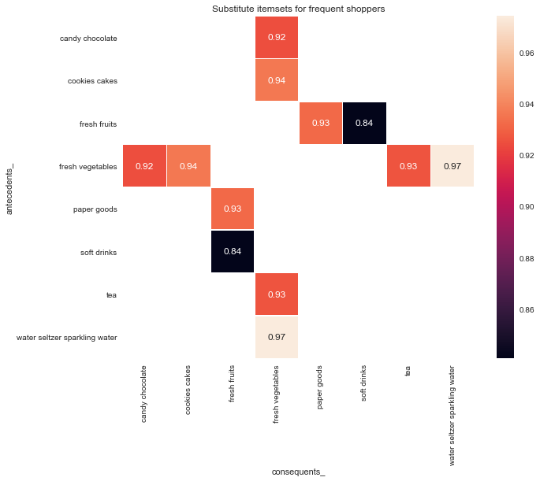

```python
# Import seaborn under its standard alias
import seaborn as sns

# Replace frozen sets with strings
rulesLift2_freq_sub['antecedents_'] = rulesLift2_freq_sub['antecedents'].apply(lambda a: ','.join(list(a)))
rulesLift2_freq_sub['consequents_'] = rulesLift2_freq_sub['consequents'].apply(lambda a: ','.join(list(a)))


# Transform the DataFrame of rules into a matrix using the lift metric
pivot = rulesLift2_freq_sub[rulesLift2_freq_sub['length_ant']==1].pivot(index = 'antecedents_',
                    columns = 'consequents_', values= 'lift')

# Generate a heatmap with annotations on and the colorbar off
fig, ax = plt.subplots(figsize=(10,8))
sns.heatmap(pivot, annot = True,linewidths=.5,ax=ax).set_title("Substitute itemsets for frequent shoppers")
plt.yticks(rotation=0)
plt.xticks(rotation=90)
plt.savefig('heatmap_freq_sub.png',bbox_inches='tight',dpi=250)
plt.show()
```

## 4.3. MBA for Cluster 3 - Occasional shoppers

```python
pt_three.head()
```

| product_name order_id | air fresheners candles | asian foods | baby accessories | baby bath body care | baby food formula | bakery desserts | baking ingredients | baking supplies decor | beauty | beers coolers | ... | spreads | tea | tofu meat alternatives | tortillas flat bread | trail mix snack mix | trash bags liners | vitamins supplements | water seltzer sparkling water | white wines | yogurt |
| --- | --- | --- | --- | --- | --- | --- | --- | --- | --- | --- | --- | --- | --- | --- | --- | --- | --- | --- | --- | --- | --- |
| 11 | 0.0 | 0.0 | 0.0 | 0.0 | 0.0 | 0.0 | 0.0 | 0.0 | 0.0 | 0.0 | ... | 0.0 | 0.0 | 0.0 | 0.0 | 0.0 | 0.0 | 0.0 | 0.0 | 0.0 | 0.0 |
| 38 | 0.0 | 0.0 | 0.0 | 0.0 | 0.0 | 0.0 | 0.0 | 0.0 | 0.0 | 0.0 | ... | 0.0 | 0.0 | 0.0 | 0.0 | 0.0 | 0.0 | 0.0 | 0.0 | 0.0 | 0.0 |
| 243 | 0.0 | 0.0 | 0.0 | 0.0 | 0.0 | 0.0 | 0.0 | 0.0 | 0.0 | 0.0 | ... | 0.0 | 0.0 | 0.0 | 0.0 | 0.0 | 0.0 | 0.0 | 0.0 | 0.0 | 0.0 |
| 471 | 0.0 | 0.0 | 0.0 | 0.0 | 0.0 | 0.0 | 0.0 | 0.0 | 0.0 | 0.0 | ... | 0.0 | 0.0 | 0.0 | 0.0 | 0.0 | 0.0 | 0.0 | 0.0 | 0.0 | 0.0 |
| 556 | 0.0 | 0.0 | 0.0 | 0.0 | 0.0 | 0.0 | 0.0 | 0.0 | 0.0 | 0.0 | ... | 0.0 | 0.0 | 0.0 | 0.0 | 0.0 | 0.0 | 0.0 | 0.0 | 0.0 | 0.0 |

5 rows × 134 columns

### 4.3.1 Support

```python
# Apply the APRIORI algorithm to get frequent itemsets
frequent_itemsets_occ = apriori(pt_three, min_support=0.05, use_colnames=True)
frequent_itemsets_occ.head()
```

|  | support | itemsets |
| --- | --- | --- |
| 0 | 0.075564 | (baking ingredients) |
| 1 | 0.160184 | (bread) |
| 2 | 0.064338 | (breakfast bakery) |
| 3 | 0.078237 | (butter) |
| 4 | 0.059747 | (candy chocolate) |

### 4.3.2 Support itemsets descending by support value

```python
frequent_itemsets_occ.sort_values(by='support', ascending=False).reset_index(drop=True).head(20)
```

|  | support | itemsets |
| --- | --- | --- |
| 0 | 0.500456 | (fresh fruits) |
| 1 | 0.427754 | (fresh vegetables) |
| 2 | 0.345272 | (packaged vegetables fruits) |
| 3 | 0.296846 | (fresh vegetables, fresh fruits) |
| 4 | 0.245590 | (fresh fruits, packaged vegetables fruits) |
| 5 | 0.243231 | (yogurt) |
| 6 | 0.230747 | (packaged cheese) |
| 7 | 0.226691 | (fresh vegetables, packaged vegetables fruits) |
| 8 | 0.210717 | (milk) |
| 9 | 0.197950 | (water seltzer sparkling water) |
| 10 | 0.177887 | (chips pretzels) |
| 11 | 0.176472 | (fresh vegetables, fresh fruits, packaged vege... |
| 12 | 0.169523 | (fresh fruits, yogurt) |
| 13 | 0.162007 | (soy lactosefree) |
| 14 | 0.160184 | (bread) |
| 15 | 0.145499 | (packaged cheese, fresh fruits) |
| 16 | 0.143706 | (eggs) |
| 17 | 0.141285 | (fresh vegetables, yogurt) |
| 18 | 0.136442 | (fresh vegetables, packaged cheese) |
| 19 | 0.134839 | (fresh fruits, milk) |

```python
# Complementary and substitute products
rulesLift2_occ = association_rules(frequent_itemsets_occ, metric="lift", min_threshold=0.01)
```

```python
rulesLift2_occ['length_ant'] = rulesLift2_occ['antecedents'].apply(lambda x: len(x))
rulesLift2_occ['length_cons'] = rulesLift2_occ['consequents'].apply(lambda x: len(x))
```

### 4.3.3 Complementary itemsets for occasional shoppers

```python
# Complementary products
rulesLift2_occ.sort_values(by='lift', ascending=False, inplace=True)
rulesLift2_occ_com = rulesLift2_occ[(rulesLift2_occ['length_ant'] <= 1) &
                                    (rulesLift2_occ['length_cons'] <= 1) &
                                    (rulesLift2_occ['lift'] > 1) &
                                    (rulesLift2_occ['conviction'] >= 1.3)].sort_values(
    by=['lift','conviction'], ascending = False).reset_index(drop=True)
rulesLift2_occ_com.iloc[:,:9]
```

|  | antecedents | consequents | antecedent support | consequent support | support | confidence | lift | leverage | conviction |
| --- | --- | --- | --- | --- | --- | --- | --- | --- | --- |
| 0 | (fresh herbs) | (fresh vegetables) | 0.088834 | 0.427754 | 0.075627 | 0.851327 | 1.990227 | 0.037628 | 3.849037 |
| 1 | (canned jarred vegetables) | (fresh vegetables) | 0.076130 | 0.427754 | 0.057357 | 0.753408 | 1.761311 | 0.024792 | 2.320616 |
| 2 | (canned meals beans) | (fresh vegetables) | 0.075564 | 0.427754 | 0.054244 | 0.717853 | 1.678191 | 0.021921 | 2.028182 |
| 3 | (frozen produce) | (packaged vegetables fruits) | 0.127229 | 0.345272 | 0.068897 | 0.541522 | 1.568393 | 0.024969 | 1.428048 |
| 4 | (fresh vegetables) | (packaged vegetables fruits) | 0.427754 | 0.345272 | 0.226691 | 0.529957 | 1.534895 | 0.078999 | 1.392909 |
| 5 | (packaged vegetables fruits) | (fresh vegetables) | 0.345272 | 0.427754 | 0.226691 | 0.656557 | 1.534895 | 0.078999 | 1.666206 |
| 6 | (fresh dips tapenades) | (packaged vegetables fruits) | 0.105060 | 0.345272 | 0.055596 | 0.529183 | 1.532654 | 0.019322 | 1.390620 |
| 7 | (soup broth bouillon) | (fresh vegetables) | 0.093834 | 0.427754 | 0.061445 | 0.654826 | 1.530847 | 0.021307 | 1.657847 |
| 8 | (frozen produce) | (fresh vegetables) | 0.127229 | 0.427754 | 0.081601 | 0.641374 | 1.499400 | 0.027179 | 1.595664 |
| 9 | (fresh herbs) | (fresh fruits) | 0.088834 | 0.500456 | 0.065281 | 0.734867 | 1.468395 | 0.020824 | 1.884128 |
| 10 | (eggs) | (packaged vegetables fruits) | 0.143706 | 0.345272 | 0.072671 | 0.505689 | 1.464611 | 0.023053 | 1.324527 |
| 11 | (other creams cheeses) | (fresh vegetables) | 0.086632 | 0.427754 | 0.053583 | 0.618512 | 1.445953 | 0.016526 | 1.500036 |
| 12 | (eggs) | (fresh vegetables) | 0.143706 | 0.427754 | 0.088802 | 0.617943 | 1.444623 | 0.027331 | 1.497804 |
| 13 | (lunch meat) | (packaged vegetables fruits) | 0.102355 | 0.345272 | 0.050816 | 0.496467 | 1.437900 | 0.015476 | 1.300268 |
| 14 | (frozen produce) | (fresh fruits) | 0.127229 | 0.500456 | 0.090941 | 0.714780 | 1.428258 | 0.027268 | 1.751434 |
| 15 | (packaged vegetables fruits) | (fresh fruits) | 0.345272 | 0.500456 | 0.245590 | 0.711293 | 1.421290 | 0.072796 | 1.730282 |
| 16 | (yogurt) | (fresh fruits) | 0.243231 | 0.500456 | 0.169523 | 0.696962 | 1.392654 | 0.047796 | 1.648453 |
| 17 | (fresh vegetables) | (fresh fruits) | 0.427754 | 0.500456 | 0.296846 | 0.693965 | 1.386665 | 0.082774 | 1.632308 |
| 18 | (fresh fruits) | (fresh vegetables) | 0.500456 | 0.427754 | 0.296846 | 0.593151 | 1.386665 | 0.082774 | 1.406532 |
| 19 | (packaged cheese) | (fresh vegetables) | 0.230747 | 0.427754 | 0.136442 | 0.591306 | 1.382350 | 0.037739 | 1.400181 |
| 20 | (fresh dips tapenades) | (fresh vegetables) | 0.105060 | 0.427754 | 0.061696 | 0.587249 | 1.372867 | 0.016757 | 1.386421 |
| 21 | (canned meals beans) | (fresh fruits) | 0.075564 | 0.500456 | 0.051413 | 0.680400 | 1.359559 | 0.013597 | 1.563026 |
| 22 | (yogurt) | (fresh vegetables) | 0.243231 | 0.427754 | 0.141285 | 0.580866 | 1.357945 | 0.037242 | 1.365307 |
| 23 | (soy lactosefree) | (fresh vegetables) | 0.162007 | 0.427754 | 0.093834 | 0.579193 | 1.354032 | 0.024534 | 1.359876 |
| 24 | (lunch meat) | (fresh vegetables) | 0.102355 | 0.427754 | 0.058489 | 0.571429 | 1.335882 | 0.014706 | 1.335241 |
| 25 | (eggs) | (fresh fruits) | 0.143706 | 0.500456 | 0.095657 | 0.665646 | 1.330078 | 0.023739 | 1.494055 |
| 26 | (soy lactosefree) | (fresh fruits) | 0.162007 | 0.500456 | 0.107701 | 0.664790 | 1.328369 | 0.026623 | 1.490244 |
| 27 | (fresh dips tapenades) | (fresh fruits) | 0.105060 | 0.500456 | 0.069243 | 0.659084 | 1.316967 | 0.016665 | 1.465300 |
| 28 | (energy granola bars) | (fresh fruits) | 0.080438 | 0.500456 | 0.052451 | 0.652072 | 1.302956 | 0.012196 | 1.435768 |
| 29 | (lunch meat) | (fresh fruits) | 0.102355 | 0.500456 | 0.066161 | 0.646390 | 1.291602 | 0.014937 | 1.412698 |
| 30 | (spreads) | (fresh fruits) | 0.079777 | 0.500456 | 0.051413 | 0.644462 | 1.287750 | 0.011488 | 1.405037 |
| 31 | (bread) | (fresh fruits) | 0.160184 | 0.500456 | 0.103204 | 0.644287 | 1.287401 | 0.023039 | 1.404347 |
| 32 | (milk) | (fresh fruits) | 0.210717 | 0.500456 | 0.134839 | 0.639904 | 1.278643 | 0.029384 | 1.387254 |
| 33 | (packaged cheese) | (fresh fruits) | 0.230747 | 0.500456 | 0.145499 | 0.630553 | 1.259958 | 0.030020 | 1.352141 |
| 34 | (other creams cheeses) | (fresh fruits) | 0.086632 | 0.500456 | 0.054086 | 0.624319 | 1.247501 | 0.010731 | 1.329704 |
| 35 | (soup broth bouillon) | (fresh fruits) | 0.093834 | 0.500456 | 0.058520 | 0.623660 | 1.246183 | 0.011561 | 1.327373 |

```python
rulesLift2_occ_com_20 = rulesLift2_occ_com[:20]
```

### 4.3.4 Complementary itemsets for occasional shoppers - Top 20

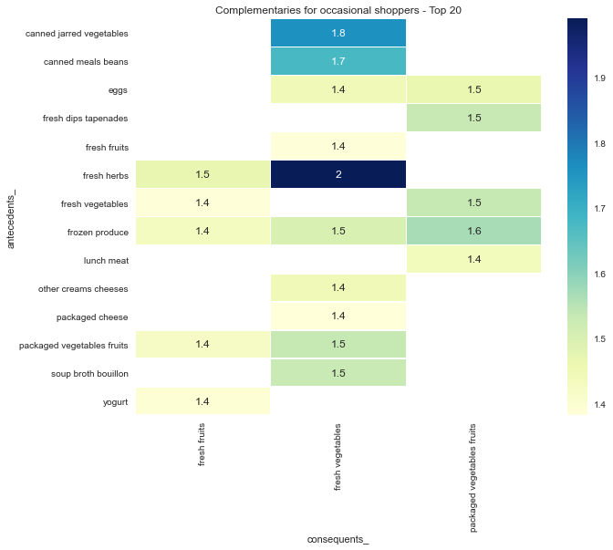

```python
# Import seaborn under its standard alias
import seaborn as sns

# Replace frozen sets with strings
rulesLift2_occ_com_20['antecedents_'] = rulesLift2_occ_com_20['antecedents'].apply(lambda a: ','.join(list(a)))
rulesLift2_occ_com_20['consequents_'] = rulesLift2_occ_com_20['consequents'].apply(lambda a: ','.join(list(a)))


# Transform the DataFrame of rules into a matrix using the lift metric
pivot = rulesLift2_occ_com_20[rulesLift2_occ_com_20['length_ant']==1].pivot(index = 'antecedents_',
                    columns = 'consequents_', values= 'lift')

# Generate a heatmap with annotations on and the colorbar off
fig, ax = plt.subplots(figsize=(10,8))
sns.heatmap(pivot, annot = True,linewidths=.5,ax=ax, cmap="YlGnBu").set_title("Complementaries for occasional shoppers - Top 20")
plt.yticks(rotation=0)
plt.xticks(rotation=90)
plt.savefig('Occ_coms_heatmap.png',bbox_inches='tight',dpi=250, transparent=True)
plt.show()
```

### 4.3.5 Substitute itemsets for occasional shoppers

```python
rulesLift2_occ
```

|  | antecedents | consequents | antecedent support | consequent support | support | confidence | lift | leverage | conviction | length_ant | length_cons |
| --- | --- | --- | --- | --- | --- | --- | --- | --- | --- | --- | --- |
| 201 | (fresh herbs) | (fresh vegetables, fresh fruits) | 0.088834 | 0.296846 | 0.058363 | 0.656991 | 2.213239 | 0.031993 | 2.049959 | 1 | 2 |
| 196 | (fresh vegetables, fresh fruits) | (fresh herbs) | 0.296846 | 0.088834 | 0.058363 | 0.196610 | 2.213239 | 0.031993 | 1.134152 | 2 | 1 |
| 376 | (fresh fruits, packaged vegetables fruits) | (fresh vegetables, yogurt) | 0.245590 | 0.141285 | 0.073928 | 0.301024 | 2.130620 | 0.039230 | 1.228534 | 2 | 2 |
| 373 | (fresh vegetables, yogurt) | (fresh fruits, packaged vegetables fruits) | 0.141285 | 0.245590 | 0.073928 | 0.523258 | 2.130620 | 0.039230 | 1.582430 | 2 | 2 |
| 199 | (fresh vegetables) | (fresh fruits, fresh herbs) | 0.427754 | 0.065281 | 0.058363 | 0.136440 | 2.090050 | 0.030439 | 1.082403 | 1 | 2 |
| ... | ... | ... | ... | ... | ... | ... | ... | ... | ... | ... | ... |
| 234 | (fresh vegetables, fresh fruits) | (water seltzer sparkling water) | 0.296846 | 0.197950 | 0.060973 | 0.205403 | 1.037650 | 0.002212 | 1.009379 | 2 | 1 |
| 85 | (fresh fruits) | (water seltzer sparkling water) | 0.500456 | 0.197950 | 0.101884 | 0.203582 | 1.028451 | 0.002818 | 1.007071 | 1 | 1 |
| 84 | (water seltzer sparkling water) | (fresh fruits) | 0.197950 | 0.500456 | 0.101884 | 0.514694 | 1.028451 | 0.002818 | 1.029339 | 1 | 1 |
| 113 | (fresh vegetables) | (water seltzer sparkling water) | 0.427754 | 0.197950 | 0.083488 | 0.195178 | 0.985995 | -0.001186 | 0.996555 | 1 | 1 |
| 112 | (water seltzer sparkling water) | (fresh vegetables) | 0.197950 | 0.427754 | 0.083488 | 0.421763 | 0.985995 | -0.001186 | 0.989640 | 1 | 1 |

382 rows × 11 columns

```python
# Substitute products
rulesLift2_occ.sort_values(by='lift', ascending=True, inplace=True)
rulesLift2_occ_sub = rulesLift2_occ[(rulesLift2_occ['length_ant'] == 1) &
                                    (rulesLift2_occ['length_cons'] == 1) &
                                    (rulesLift2_occ['lift'] < 1)].sort_values(by='lift', ascending = True).reset_index(drop=True)
rulesLift2_occ_sub.iloc[:,:9]
```

|  | antecedents | consequents | antecedent support | consequent support | support | confidence | lift | leverage | conviction |
| --- | --- | --- | --- | --- | --- | --- | --- | --- | --- |
| 0 | (water seltzer sparkling water) | (fresh vegetables) | 0.197950 | 0.427754 | 0.083488 | 0.421763 | 0.985995 | -0.001186 | 0.989640 |
| 1 | (fresh vegetables) | (water seltzer sparkling water) | 0.427754 | 0.197950 | 0.083488 | 0.195178 | 0.985995 | -0.001186 | 0.996555 |

### 4.3.6 Heatmap - Substitute itemsets for occasional shoppers

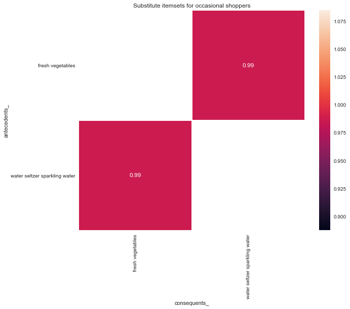

```python
# Import seaborn under its standard alias
import seaborn as sns

# Replace frozen sets with strings
rulesLift2_occ_sub['antecedents_'] = rulesLift2_occ_sub['antecedents'].apply(lambda a: ','.join(list(a)))
rulesLift2_occ_sub['consequents_'] = rulesLift2_occ_sub['consequents'].apply(lambda a: ','.join(list(a)))


# Transform the DataFrame of rules into a matrix using the lift metric
pivot = rulesLift2_occ_sub[rulesLift2_occ_sub['length_ant']==1].pivot(index = 'antecedents_',
                    columns = 'consequents_', values= 'lift')

# Generate a heatmap with annotations on and the colorbar off
fig, ax = plt.subplots(figsize=(10,8))
sns.heatmap(pivot, annot = True,linewidths=.5,ax=ax).set_title("Substitute itemsets for occasional shoppers")
plt.yticks(rotation=0)
plt.xticks(rotation=90)
plt.savefig('heatmap_sub_occ_20.png',bbox_inches='tight',dpi=250)
plt.show()
```

```python
rulesLift2_occ_com_20
```

|  | antecedents | consequents | antecedent support | consequent support | support | confidence | lift | leverage | conviction | length_ant | length_cons | antecedents_ | consequents_ |
| --- | --- | --- | --- | --- | --- | --- | --- | --- | --- | --- | --- | --- | --- |
| 0 | (fresh herbs) | (fresh vegetables) | 0.088834 | 0.427754 | 0.075627 | 0.851327 | 1.990227 | 0.037628 | 3.849037 | 1 | 1 | fresh herbs | fresh vegetables |
| 1 | (canned jarred vegetables) | (fresh vegetables) | 0.076130 | 0.427754 | 0.057357 | 0.753408 | 1.761311 | 0.024792 | 2.320616 | 1 | 1 | canned jarred vegetables | fresh vegetables |
| 2 | (canned meals beans) | (fresh vegetables) | 0.075564 | 0.427754 | 0.054244 | 0.717853 | 1.678191 | 0.021921 | 2.028182 | 1 | 1 | canned meals beans | fresh vegetables |
| 3 | (frozen produce) | (packaged vegetables fruits) | 0.127229 | 0.345272 | 0.068897 | 0.541522 | 1.568393 | 0.024969 | 1.428048 | 1 | 1 | frozen produce | packaged vegetables fruits |
| 4 | (fresh vegetables) | (packaged vegetables fruits) | 0.427754 | 0.345272 | 0.226691 | 0.529957 | 1.534895 | 0.078999 | 1.392909 | 1 | 1 | fresh vegetables | packaged vegetables fruits |
| 5 | (packaged vegetables fruits) | (fresh vegetables) | 0.345272 | 0.427754 | 0.226691 | 0.656557 | 1.534895 | 0.078999 | 1.666206 | 1 | 1 | packaged vegetables fruits | fresh vegetables |
| 6 | (fresh dips tapenades) | (packaged vegetables fruits) | 0.105060 | 0.345272 | 0.055596 | 0.529183 | 1.532654 | 0.019322 | 1.390620 | 1 | 1 | fresh dips tapenades | packaged vegetables fruits |
| 7 | (soup broth bouillon) | (fresh vegetables) | 0.093834 | 0.427754 | 0.061445 | 0.654826 | 1.530847 | 0.021307 | 1.657847 | 1 | 1 | soup broth bouillon | fresh vegetables |
| 8 | (frozen produce) | (fresh vegetables) | 0.127229 | 0.427754 | 0.081601 | 0.641374 | 1.499400 | 0.027179 | 1.595664 | 1 | 1 | frozen produce | fresh vegetables |
| 9 | (fresh herbs) | (fresh fruits) | 0.088834 | 0.500456 | 0.065281 | 0.734867 | 1.468395 | 0.020824 | 1.884128 | 1 | 1 | fresh herbs | fresh fruits |
| 10 | (eggs) | (packaged vegetables fruits) | 0.143706 | 0.345272 | 0.072671 | 0.505689 | 1.464611 | 0.023053 | 1.324527 | 1 | 1 | eggs | packaged vegetables fruits |
| 11 | (other creams cheeses) | (fresh vegetables) | 0.086632 | 0.427754 | 0.053583 | 0.618512 | 1.445953 | 0.016526 | 1.500036 | 1 | 1 | other creams cheeses | fresh vegetables |
| 12 | (eggs) | (fresh vegetables) | 0.143706 | 0.427754 | 0.088802 | 0.617943 | 1.444623 | 0.027331 | 1.497804 | 1 | 1 | eggs | fresh vegetables |
| 13 | (lunch meat) | (packaged vegetables fruits) | 0.102355 | 0.345272 | 0.050816 | 0.496467 | 1.437900 | 0.015476 | 1.300268 | 1 | 1 | lunch meat | packaged vegetables fruits |
| 14 | (frozen produce) | (fresh fruits) | 0.127229 | 0.500456 | 0.090941 | 0.714780 | 1.428258 | 0.027268 | 1.751434 | 1 | 1 | frozen produce | fresh fruits |
| 15 | (packaged vegetables fruits) | (fresh fruits) | 0.345272 | 0.500456 | 0.245590 | 0.711293 | 1.421290 | 0.072796 | 1.730282 | 1 | 1 | packaged vegetables fruits | fresh fruits |
| 16 | (yogurt) | (fresh fruits) | 0.243231 | 0.500456 | 0.169523 | 0.696962 | 1.392654 | 0.047796 | 1.648453 | 1 | 1 | yogurt | fresh fruits |
| 17 | (fresh vegetables) | (fresh fruits) | 0.427754 | 0.500456 | 0.296846 | 0.693965 | 1.386665 | 0.082774 | 1.632308 | 1 | 1 | fresh vegetables | fresh fruits |
| 18 | (fresh fruits) | (fresh vegetables) | 0.500456 | 0.427754 | 0.296846 | 0.593151 | 1.386665 | 0.082774 | 1.406532 | 1 | 1 | fresh fruits | fresh vegetables |
| 19 | (packaged cheese) | (fresh vegetables) | 0.230747 | 0.427754 | 0.136442 | 0.591306 | 1.382350 | 0.037739 | 1.400181 | 1 | 1 | packaged cheese | fresh vegetables |